# RepRes_proj1

JRB

04/19/2015

### Step 1. Loading and preprocessing the data

Load the data (i.e. read.csv()) Process/transform the data (if necessary) into a format suitable for your analysis

```r
Data <- read.csv(file="/home/broughma/rwork/activity.csv", header=TRUE)
Data$date <- as.Date(Data$date)
Data$fac <- cut(Data$date, breaks="day")
```

Next we can check the data structure and see if the data is adequate for analysis

```r
str(Data)
```

```
## 'data.frame':    17568 obs. of  4 variables:
##  $ steps   : int  NA NA NA NA NA NA NA NA NA NA ...
##  $ date    : Date, format: "2012-10-01" "2012-10-01" ...
##  $ interval: int  0 5 10 15 20 25 30 35 40 45 ...
##  $ fac     : Factor w/ 61 levels "2012-10-01","2012-10-02",..: 1 1 1 1 1 1 1 1 1 1 ...
```

```r
summary(Data)
```

```
##      steps             date               interval              fac
##  Min.   :  0.00   Min.   :2012-10-01   Min.   :   0.0   2012-10-01:  288
##  1st Qu.:  0.00   1st Qu.:2012-10-16   1st Qu.: 588.8   2012-10-02:  288
##  Median :  0.00   Median :2012-10-31   Median :1177.5   2012-10-03:  288
##  Mean   : 37.38   Mean   :2012-10-31   Mean   :1177.5   2012-10-04:  288
##  3rd Qu.: 12.00   3rd Qu.:2012-11-15   3rd Qu.:1766.2   2012-10-05:  288
##  Max.   :806.00   Max.   :2012-11-30   Max.   :2355.0   2012-10-06:  288
##  NA's   :2304                                           (Other)   :15840
```

### 2. What is mean total number of steps taken per day? (ignore the missing values in the dataset)

Calculate the total number of steps taken per day Make a histogram of the total number of steps taken each day Calculate and report the mean and median of the total number of steps taken per day

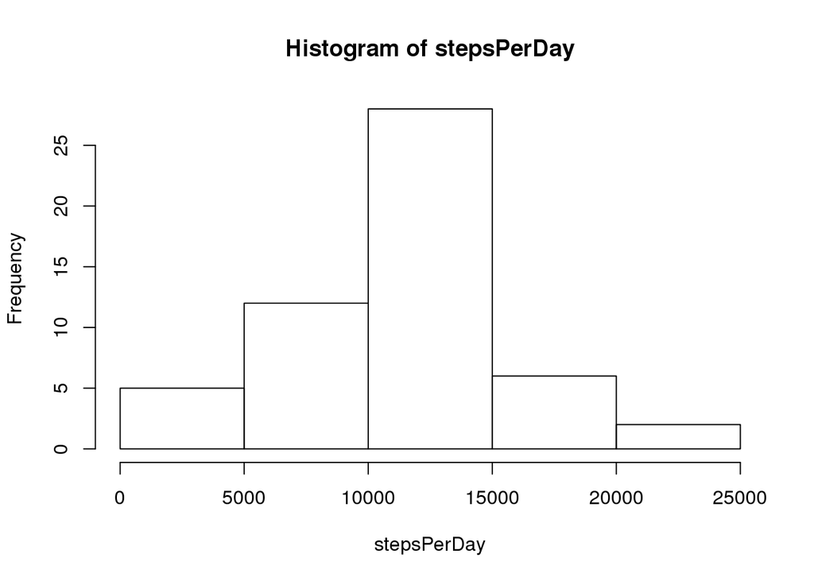

```r
stepsPerDay <- tapply(Data$steps, Data$fac, sum)
hist(stepsPerDay)
```

```r
aggregateData <- aggregate(steps ~ date, data = Data, sum, na.rm = TRUE)
stepsPerDayMean <- mean(aggregateData$steps)
stepsPerDayMedian <- median(aggregateData$steps)
stepsPerDayMean
```

```
## [1] 10766.19
```

```r
stepsPerDayMedian
```

```
## [1] 10765
```

### 3. What is the average daily activity pattern?

Make a time series plot of the 5-minute interval and the average number of steps taken,averaged across all days (y-axis) Which 5-minute interval, on average across all the days in the dataset,contains the maximum number of steps?

```r
stepsPerInterval <- aggregate(steps ~ interval, data = Data, mean, na.rm = TRUE)
stepsPerInterval[which.max(stepsPerInterval$steps), ]$interval
```

```
## [1] 835
```

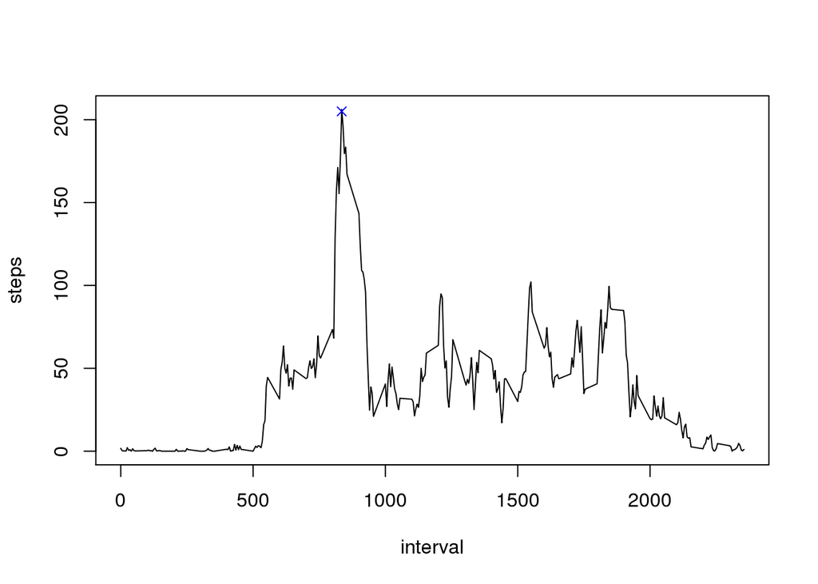

```r
plot(steps~interval, data=stepsPerInterval, type="l")
points(835, 205, pch=4, col=4)
```

### 4. Imputing missing values

Calculate and report the total number of missing values in the dataset (i.e. the total number of rows with NAs) Devise a strategy for filling in all of the missing values in the dataset. The strategy does not need to be sophisticated. For example, you could use the mean/median for that day, or the mean for that 5-minute interval, etc.

```r
missingSteps <- sum(is.na(Data$steps))
missingSteps
```

```
## [1] 2304
```

```r
filledData <- Data
for (i in 1:nrow(filledData)){
        if (is.na(filledData$steps[i])){
                intervalValue <- filledData$interval[i]
                identifier <- which(stepsPerInterval$interval == intervalValue)
                steps <- stepsPerInterval$steps[identifier]
                filledData$steps[i] <- steps
        }
}
print("Check to see if the NAs have been replaced, as all 6 of the header step values were NA")
```

```
## [1] "Check to see if the NAs have been replaced, as all 6 of the header step values were NA"
```

```r
head(filledData)
```

```
##       steps       date interval        fac
## 1 1.7169811 2012-10-01        0 2012-10-01
## 2 0.3396226 2012-10-01        5 2012-10-01
## 3 0.1320755 2012-10-01       10 2012-10-01
## 4 0.1509434 2012-10-01       15 2012-10-01
## 5 0.0754717 2012-10-01       20 2012-10-01
## 6 2.0943396 2012-10-01       25 2012-10-01
```